# ESM 206 Lab 5

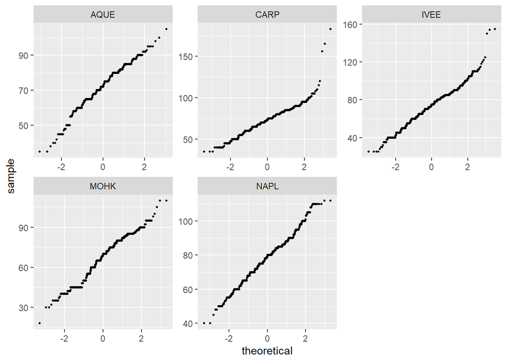

```r
ggplot(data= lobster_tidy, aes(sample = size_mm))+
  geom_qq(size = 0.7)+
  facet_wrap(~site, scales = "free")
```

convert data

```r
lobster_data <- lobster_tidy %>%
  mutate(date_new = lubridate::mdy(date))
```

parse date column to get column that has month in it. and the column already is treated as a factor w/ assigned order!

```r
lobster_parse_date <- lobster_data %>%
  mutate(obs_month = lubridate::month(date_new, label = TRUE)) %>%
  mutate(obs_year = lubridate::year(date_new))
```

count lobsters by different groupings

counting number of lobsters by yr and month

```r
lobster_ym <- lobster_parse_date %>%
  count(obs_year, obs_month)
```

counting number of lobsters by sites

```r
lobster_ysite <- lobster_parse_date %>%
  count(obs_year, site)
```

over all obs, how many lobsters at each site

```r
lobster_site_only <- lobster_parse_date %>%
  count(site)
```

stick it all in 1 table

```r
lobster_summary <- lobster_parse_date %>%
  group_by(site) %>%
  summarize(
    mean_size = mean(size_mm, na.rm = TRUE),
    sd_size = sd(size_mm, na.rm = TRUE),
    sample_n = n()
  )
```

Confidence Intervals and t-tests use ttest fxn to find confidence intervals and perform ttests

```r
ivee_lobsters <- lobster_tidy %>%
  filter(site == "IVEE") %>%
  pull(size_mm)  #store a vector of values

t.test(ivee_lobsters) #one vector, so one sample t-test (is there anough evidence that the actual value is different from zero)
```

```
##
##  One Sample t-test
##
## data:  ivee_lobsters
## t = 245.23, df = 2302, p-value < 2.2e-16
## alternative hypothesis: true mean is not equal to 0
## 95 percent confidence interval:
##  72.99130 74.16806
## sample estimates:
## mean of x
##  73.57968
```

2 sample t-test! Is there a sig dif btw mean lobs lengths btw naples reef and mohawk reef?

```r
napl_sample <- lobster_tidy %>%
  filter(site == "NAPL") %>%
  pull(size_mm)

mohk_sample <- lobster_tidy %>%
  filter(site == "MOHK") %>%
  pull(size_mm)

mohk_napl_ttest <- t.test(napl_sample,mohk_sample)

mohk_napl_ttest
```

```
##
##  Welch Two Sample t-test
##
## data:  napl_sample and mohk_sample
## t = 19.849, df = 1850.8, p-value < 2.2e-16
## alternative hypothesis: true difference in means is not equal to 0
## 95 percent confidence interval:
##  10.19806 12.43436
## sample estimates:
## mean of x mean of y
##  78.18454  66.86833
```

(in help documentation, the value section refers to all the outputs of a fxn. use them to call/reference them!)

mean lobster size differed significatly btw Mohawk and Naples reefs(t(1850.7720862) = 19.8487322)

```r
lobster_2sample <- lobster_tidy %>%
  filter(site %in% c("NAPL","MOHK"))

ttest_2 <- t.test(size_mm ~ site, data = lobster_2sample)
ttest_2
```

```
##
##  Welch Two Sample t-test
##
## data:  size_mm by site
## t = -19.849, df = 1850.8, p-value < 2.2e-16
## alternative hypothesis: true difference in means is not equal to 0
## 95 percent confidence interval:
##  -12.43436 -10.19806
## sample estimates:
## mean in group MOHK mean in group NAPL
##           66.86833           78.18454
```

make a heat map!

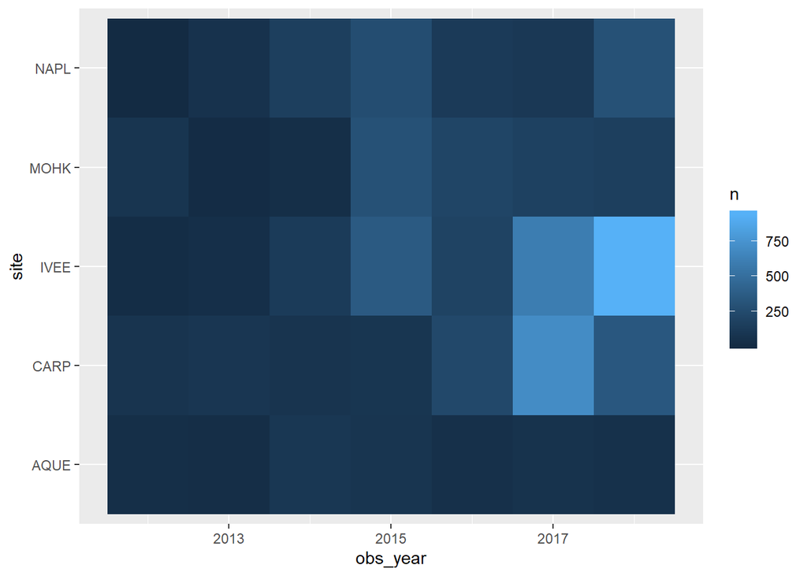

```r
ggplot(data = lobster_ysite, aes(x = obs_year, y = site)) +
  geom_tile(aes(fill = n))
```